# ISA 491 Apenndix - Jacob Igel & Elliott Kelley

November 30, 2021

### Reading in Data

```r
pacman::p_load(tidyverse, doParallel, nnet, caret, ranger, ROCR, gbm, xgboost, pROC, fastDummies, NeuralNetTools)

domestic <- readRDS("ISA491Project_clean2.RDS")
rforest <- readRDS("rforest_final.RDS")
gb.tree <- readRDS("gbtree_final.RDS")
r.gbtree.auc.t <-readRDS("pgb_training.RDS")
r.gbtree.auc <- readRDS("pgb_valid.RDS")

xgboost <- readRDS("xgboost_final.rds")
r.xgboost.auc.t <- readRDS("pxgb_training.RDS")
r.xgboost.auc <- readRDS("pxgb_valid.RDS")

lrstep<-readRDS("lrstep1.RDS")
step2 <-readRDS("f.RDS")
nnetFit<-readRDS("nnet_final.RDS")

training<-readRDS("training_final.RDS")
valid<-readRDS("valid_final.RDS")
trainIndex<-readRDS("trainIndex_final.RDS")

x <-readRDS("x_final.RDS")
y <-readRDS("y_final.RDS")

p.xgboost <- readRDS("p.xgboost_final.RDS")
p.gbtree <- readRDS("p.gbtree_final.RDS")
```

### Data Pre-Processing

#### Subset Data

2005, 2006, 2009, 2010 were all years that Miami admission was not “normal” so because of that we want to consolidate the data to the “Normal” years of operation.

We are using DateFrom to remove these dates instead of DataFrom since it ranges from 2005 - 2017 instead of 2006 - 2015. They are the exact same variable.

With these variables removed, we now have 9 “Normal” years that we want to compare to 2018 since it is the most recent information that we have. Along those lines, we want to use 2018 as a sort of “base-line” for which variables we find important or not

```r
domestic <- filter(domestic, (DateFrom != "2005"))
domestic <- filter(domestic, (DateFrom != "2006"))
domestic <- filter(domestic, (DateFrom != "2009"))
domestic <- filter(domestic, (DateFrom != "2010"))
```

#### Dummy Variables

To make sure that are cleaning this data properly, every variable that has two levels or above needs to be put into a dummy variable so that is what we are doing here.

```r
domestic <-dummy_columns(domestic, select_columns = c("AlumniConnection","Division"
                                                      ,"Major", "Status", "StateResidency",
                                                      "ApplicationType", "SpecialConsideration",
                                                      "Question", "Decision", "DecisionType",
                                                      "Harrison", "HsType", "ON",
                                                      "VisaType", "MiamiRanks"),
                         remove_first_dummy = TRUE,
                         remove_selected_columns = TRUE)

domestic <-dummy_columns(domestic, select_columns = c("HomeState",
                                                      "CountyDesc", "CountyCode",
                                                      "HighSchoolState",
                                                      "SuppMajor1","SuppMajor3", "FullRace",
                                                      "WhichTestBest", "DEC",
                                                      "Concentration"),
                         remove_first_dummy = TRUE,
                         remove_selected_columns = TRUE)
```

#### Remove Variables

1. Most of these variables are being dropped due to the large proportion of missing values that they have.
2. Taking this out since we can just use Miami Ranks.
3. Taking these out since there is about 70% missing and we feel as if these would be difficult to impute with that amount missing.
4. The rest of the variables that we took out were ones that were mostly zeros in our bar graphs and the last minute variables that we decided to get rid of.

```r
#1)
domestic <-select(domestic, -starts_with("TIB"), -starts_with("TOEFL"),
                  -starts_with("IELTS"), -starts_with("ACTMax"), -starts_with("TCP"),
                  -"tag",-"VentureScholar", -"RoundedGPA",
                  -"HS.Code", -"Super.ACT", -"IELL", -"IELR", -"IELW", -"IELS",
                  -"IELO", -"VisaType", -"InternationalFlag", -"NatlAch", -"NatlHisp",
                  -"CanCode", -"X__1", -"FAFSA_RECV_Date", -"Which.Test", -"Language",
                  -"DEC", -"SAT.R.ERW", -"ConfirmDate", -"SAT.R.Math", -"ACTWritingMax",
                  -"CEEB5", -"AIDY_Code", -"Act25", -"Act75", -"Retained_recode",
                  -"GPAScale", -"OriginalGPA")

#2)
domestic <-select(domestic, -"FirstSchool", -"SecondSchool", -"ThirdSchool",
                  -"FourthSchool", -"FifthSchool", -"SixthSchool", -"SeventhSchool",
                  -"EighthSchool", -"TenthSchool")

#3)
domestic <- select(domestic, -starts_with("SAT"))

domestic <-select(domestic, -"AlumniConnection_D",-"AlumniConnection_D - Father, Sibling",-starts_with("Major_"), -"StateResidency_Z",
                  -"Decision_", -"DecisionType_DN",-"DecisionType_DQ",-"DecisionType_E",
                  -"DecisionType_HN",-"DecisionType_HQ",-"DecisionType_HY", -"DecisionType_KN",
                  -"DecisionType_KQ",-"DecisionType_KY",-"DecisionType_N",
                  -"DecisionType_SN",-"DecisionType_SQ",-"DecisionType_SY",
                  -starts_with("AlumniConnection_B"))

#4)
domestic <-select(domestic, -"MiamiRanks_9", -"MiamiRanks_10", -"MiamiRanks_S",
                  -"HighSchoolState_AR", -"HighSchoolState_DE",
                  -"HighSchoolState_OR",-"MiamiRanks_8",
                  -"MiamiRanks_7", -"MiamiRanks_6", -"MiamiRanks_5", -"ON_8",
                  -"ON_7", -"ON_6", -"ON_5", -"HsType_Unknown", -"HsType_Private Secular",
                  -"HsType_Home School", -"HsType_Charter", -"HsType_4", -"DecisionType_S",
                  -"ApplicationType_OI", -"HsType_Religious",
                  -"Division_CCA", -"AlumniConnection_M - Mother",
                  -"AlumniConnection_F - Father",
                  -"AlumniConnection_C - Mother, Sibling", -"AlumniConnection_C",
                  -"AlumniConnection_A", -"Citizenship2",
                  -"AlumniConnection_A - Mother, Father, Sibling", -"MiamiRanks_4")


domestic <-select(domestic, -"SuppMajor3_AP56", -"SuppMajor3_AS47", -"SuppMajor3_AS86",
                  -"SuppMajor3_ASBC", -"SuppMajor3_ASBP" , -"SuppMajor3_ASEV",
                  -"SuppMajor3_ASIN",
                  -"SuppMajor3_ASJN", -"SuppMajor3_ASSW", -"SuppMajor3_ASU1",
                  -"SuppMajor3_BU01",
                  -"SuppMajor3_BUIB", -"SuppMajor3_BUIS", -"SuppMajor3_EA56",
                  -"SuppMajor3_EAGA",
                  -"SuppMajor3_FA03", -"SuppMajor3_FA39")


domestic <- select(domestic, -"TermCode")
domestic <- select(domestic, -"Citizenship")

domestic <- select(domestic, -"Concentration_VO",-"Concentration_SI",-"Concentration_SH",
                   -"Concentration_SG",-"Concentration_SF",-"Concentration_SE",
                   -"Concentration_SD",-"Concentration_M2",-"Concentration_HB",
                   -"Concentration_EL",-"Concentration_89",-"Concentration_84",
                   -"Concentration_76",-"Concentration_IN")

domestic <- select(domestic, -"WhichTestBest_TIE")
domestic <- select(domestic, -"Dec")
```

#### Imputation

For df, df2, and df3, we used a function to see if the variables had above a certain percentage missing. If they did, then we both decided just to get rid of the variable since there was going to be way too much to impute at that point. Then, we used a for loop to then impute the certain variables that we decided had enough missing to impute and we replaced the missing values with the median of the given variable.

```r
df <- domestic[colSums(is.na(domestic))/nrow(domestic) > .6109]

domestic <-select(domestic, -"DataFrom", -"EER", -starts_with("ApplicationDate"),
                  -"DecisionDate", -"ACTChoice", -"Phone", -"Math",
                  -"DisciplinaryQuestion1", -"NationDesc", -"Housing", -"ACTEquivalent",
                  -"Lang", -"County", -"InitialContact", -"hs.code", -"HSClust",
                  -"EduNbrhd", -ends_with("_Race"), -"MAI", -"Bridges",
                  -"FSBDirect", -starts_with("CEEB"), -"IntlTestScoreThresholdFlag",
                  -"Com.App.Acad.Int", -"Intl.Scholarship", -"ConfirmDate_Formatted",
                  -"College.Since.9th.Grade", -"Primary_Parent_Occupation",
                  -"Sec_Parent_Occupation", -"Parent1Degree", -"Parent2Degree",
                  -"Permanent.Home", -starts_with("Zip"), -"Special.Consideration",
                  -"DecisionDateFormatted", -"ConfirmedDate",
                  -"MeritGPA", -"GPAOrig", -"Parent.1.Education.Level",
                  -"Parent.2.Educational.Level", -"Visa.Type",-"Hispanic",
                  -starts_with("SpecialConsideration_"), -starts_with("Question_"),
                  -starts_with("Harrison_"), -"FirstGen", -"DecisionDate_Formatted",
                  -"Race")


df2 <- domestic[colSums(is.na(domestic))/nrow(domestic) > .1594]

for(i in 1:ncol(domestic)) {
  domestic[ , i][is.na(domestic[ , i])] <- median(domestic[ , i], na.rm=TRUE)
}

df3 <- domestic[colSums(is.na(domestic))/nrow(domestic) > .1156]

domestic <-select(domestic, -"HighSchoolCode", -"Citizen", -"OneRace",
                  -"USStateRegion", -"Geomkt", -"Ethn_HS_YN", -"FullEthn",
                  -"FullEthn.Race", -"OhioCountyRegion", -"ACEFlag", -"MCFlag",
                  -"SuppMajor2", -"MeritGPAThresholdFlag")
```

#### Collapsing Varaibles

A lot of this code is based on the Race variable and the Major variable which were both a mess. We wanted to consolidate each category for both of those majors and then we moved on to the “smaller” stuff. This included changing variables like County Code, both the citizenships (which we ended up getting rid of anyway), Confirm Code, Which Test Best, and then changing our response variables (retained) so the 1’s were No’s and the 0’s were Yes’s.

```r
# Fixing Race -------------------------------------------------------------

domestic[domestic == "AI"] <- "American Indian or Alaska Native"
domestic[domestic == "AS"] <- "Asian"
domestic[domestic == "HS"] <- "Hispanic/Latino"
domestic[domestic == "MR"] <- "Multi Racial"
domestic$FullRace[domestic$FullRace == "NC"] <- "Multi Racial"
domestic[domestic == "PI"] <- "Native Hawaiian or Other Pacific Islander"
domestic[domestic == "SortOfIntl"] <- "Non-Resident Alien"
domestic[domestic == "Two or more races"] <- "Multi Racial"
domestic[domestic == "UK"] <- "Unknown"
domestic[domestic == "BL"] <- "Black or African American"
domestic[domestic == "WH"] <- "White"
domestic$FullRace[domestic$FullRace == "1"] <- "American Indian or Alaska Native"
domestic$FullRace[domestic$FullRace == "2"] <- "Asian"
domestic$FullRace[domestic$FullRace == "6"] <- "Hispanic/Latino"
domestic$FullRace[domestic$FullRace == "7"] <- "Multi Racial"
domestic$FullRace[domestic$FullRace == "7"] <- "Multi Racial"
domestic$FullRace[domestic$FullRace == "4"] <- "Native Hawaiian or Other Pacific Islander"
domestic$FullRace[domestic$FullRace == "9"] <- "Non-Resident Alien"
domestic$FullRace[domestic$FullRace == "7"] <- "Multi Racial"
domestic$FullRace[domestic$FullRace == "8"] <- "Unknown"
domestic$FullRace[domestic$FullRace == "3"] <- "Black or African American"
domestic$FullRace[domestic$FullRace == "5"] <- "White"
domestic[domestic == "Hispanic/Latino, White"] <- "Multi Racial"
domestic[domestic == "Asian, White"] <- "Multi Racial"
domestic[domestic == "Black or African American, White"] <- "Multi Racial"
domestic[domestic == "Native Hawaiian or Other Pacific Islander, White"] <- "Multi Racial"
domestic[domestic == "American Indian or Alaska Native, Hispanic/Latino, White"] <- "Multi Racial"
domestic[domestic == "American Indian or Alaska Native, Black or African American"] <- "Multi Racial"
domestic[domestic == "American Indian or Alaska Native, White"] <- "Multi Racial"
domestic[domestic == "Asian, Native Hawaiian or Other Pacific Islander, White"] <- "Multi Racial"
domestic[domestic == "Black or African American, Hispanic/Latino"] <- "Multi Racial"
domestic[domestic == "American Indian or Alaska Native, Asian, White"] <- "Multi Racial"
domestic[domestic == "Asian, Hispanic/Latino"] <- "Multi Racial"
domestic[domestic == "Black or African American, Hispanic/Latino, White"] <- "Multi Racial"
domestic[domestic == "Black or African American, Hispanic/Latino, White"] <- "Multi Racial"
domestic[domestic == "American Indian or Alaska Native, Hispanic/Latino"] <- "Multi Racial"
domestic[domestic == "American Indian or Alaska Native, Native Hawaiian or Other Pacific Islander, White"] <- "Multi Racial"
domestic[domestic == "Asian, Native Hawaiian or Other Pacific Islander"] <- "Multi Racial"
domestic[domestic == "Hispanic/Latino, Native Hawaiian or Other Pacific Islander, White"] <- "Multi Racial"
domestic[domestic == "Asian, Hispanic/Latino, Native Hawaiian or Other Pacific Islander, White"] <- "Multi Racial"
domestic[domestic == "American Indian or Alaska Native, Asian, Black or African American"] <- "Multi Racial"
domestic[domestic == "Asian, Black or African American, White"] <- "Multi Racial"
domestic[domestic == "Black or African American, Native Hawaiian or Other Pacific Islander, White"] <- "Multi Racial"
domestic[domestic == "Asian, Black or African American"] <- "Multi Racial"
domestic[domestic == "American Indian or Alaska Native, Black or African American, White"] <- "Multi Racial"
domestic[domestic == "Asian, Hispanic/Latino, White"] <- "Multi Racial"
domestic[domestic == "NA"] <- NA
domestic[domestic == "ASWH"] <- "Multi Racial"
domestic[domestic == "AIWH"] <- "Multi Racial"
domestic[domestic == "ASWH"] <- "Multi Racial"
domestic[domestic == "HSWH"] <- "Multi Racial"
domestic[domestic == "BLWH"] <- "Multi Racial"
domestic[domestic == "AIHSWH"] <- "Multi Racial"
domestic[domestic == "AIBLWH"] <- "Multi Racial"
domestic[domestic == "PIWH"] <- "Multi Racial"
domestic[domestic == "ASPI"] <- "Multi Racial"
domestic[domestic == "AIAS"] <- "Multi Racial"
domestic[domestic == "ASHSWH"] <- "Multi Racial"
domestic[domestic == "BLHSWH"] <- "Multi Racial"
domestic$FullRace[domestic$FullRace == "PR"] <- "Multi Racial"
domestic[domestic == "AIBLHS"] <- "Multi Racial"
domestic[domestic == "MAWH"] <- "Multi Racial"
domestic$FullRace[domestic$FullRace == "MA"] <- "Multi Racial"
domestic[domestic == "ASHS"] <- "Multi Racial"
domestic[domestic == "ASPIWH"] <- "Multi Racial"
domestic[domestic == "AIHS"] <- "Multi Racial"
domestic[domestic == "BLHS"] <- "Multi Racial"
domestic[domestic == "AIMAWH"] <- "Multi Racial"
domestic[domestic == "ASBLWH"] <- "Multi Racial"
domestic[domestic == "PRWH"] <- "Multi Racial"
domestic[domestic == "AIASMA"] <- "Multi Racial"
domestic[domestic == "AIASWH"] <- "Multi Racial"
domestic[domestic == "ASBL"] <- "Multi Racial"
domestic[domestic == "AIBL"] <- "Multi Racial"
domestic[domestic == "BLPR"] <- "Multi Racial"
domestic[domestic == "ASHSPIWH"] <- "Multi Racial"
domestic[domestic == "AIBLHSWH"] <- "Multi Racial"
domestic[domestic == "AIASBLWH"] <- "Multi Racial"
domestic[domestic == "BLPRWH"] <- "Multi Racial"
domestic[domestic == "MAPI"] <- "Multi Racial"
domestic[domestic == "AIASBL"] <- "Multi Racial"
domestic[domestic == "ASBLPIWH"] <- "Multi Racial"
domestic[domestic == "AIPIWH"] <- "Multi Racial"
domestic[domestic == "ASBLHS"] <- "Multi Racial"

# Collapsing Almost Full Race  --------------------------------------------

domestic$AlmostFullRace[domestic$AlmostFullRace=="Multi Racial"]<-"Non-White"
domestic$AlmostFullRace[domestic$AlmostFullRace=="Asian"]<-"Non-White"
domestic$AlmostFullRace[domestic$AlmostFullRace=="Black or African American"]<-"Non-White"
domestic$AlmostFullRace[domestic$AlmostFullRace=="Hispanic/Latino"]<-"Non-White"
domestic$AlmostFullRace[domestic$AlmostFullRace=="American Indian or Alaska Native"]<-"Non-White"
domestic$AlmostFullRace[domestic$AlmostFullRace=="MA"]<-"Non-White"
domestic$AlmostFullRace[domestic$AlmostFullRace=="PR"]<-"Non-White"
domestic$AlmostFullRace[domestic$AlmostFullRace=="Native Hawaiian or Other Pacific Islander"]<-"Non-White"


# Fixing Major ------------------------------------------------------------

domestic[domestic == "00US"] <- "ASU1"
domestic[domestic == "ASU2"] <- "ASU1"
domestic[domestic == "ASU3"] <- "ASU1"
domestic[domestic == "ASU4"] <- "ASU1"
domestic[domestic == "ASUS"] <- "ASU1"
domestic[domestic == "AP71"] <- "RC71"
domestic[domestic == "AP72"] <- "AS72"
domestic[domestic == "AS74"] <- "EA74"
domestic[domestic == "AP87"] <- "RC87"
domestic[domestic == "AP88"] <- "RC88"
domestic[domestic == "APAN"] <- "ASAN"
domestic[domestic == "BUAN"] <- "ASAN"
domestic[domestic == "EAAN"] <- "ASAN"
domestic[domestic == "FAAN"] <- "ASAN"
domestic[domestic == "RCAN"] <- "ASAN"
domestic[domestic == "BUEB"] <- "RCEB"
domestic[domestic == "ASEN"] <- "APEN"
domestic[domestic == "BUEN"] <- "APEN"
domestic[domestic == "EAEN"] <- "APEN"
domestic[domestic == "FAEN"] <- "APEN"
domestic[domestic == "RCEN"] <- "APEN"
domestic[domestic == "0056"] <- "00UH"
domestic[domestic == "RCEN"] <- "APEN"
domestic[domestic == "APSH"] <- "APCH"
domestic[domestic == "ASEP"] <- "BUEP"
domestic[domestic == "EAEP"] <- "BUEP"
domestic[domestic == "FAEP"] <- "BUEP"
domestic[domestic == "APEP"] <- "BUEP"
domestic[domestic == "AS76"] <- "APES"
domestic[domestic == "ASES"] <- "APES"
domestic[domestic == "BUES"] <- "APES"
domestic[domestic == "EAES"] <- "APES"
domestic[domestic == "FAES"] <- "APES"
domestic[domestic == "IS76"] <- "APES"
domestic[domestic == "ISES"] <- "APES"
domestic[domestic == "RCES"] <- "APES"
domestic[domestic == "RCET"] <- "APET"
domestic[domestic == "RCHT"] <- "APHT"
domestic[domestic == "ASIM"] <- "APIM"
domestic[domestic == "BUIM"] <- "APHT"
domestic[domestic == "EAIM"] <- "APHT"
domestic[domestic == "FAIM"] <- "APHT"
domestic[domestic == "RCIM"] <- "APHT"
domestic[domestic == "APIM"] <- "APHT"
domestic[domestic == "ASIM"] <- "APHT"
domestic[domestic == "RCK3"] <- "BUK3"
domestic[domestic == "RCKA"] <- "BUKA"
domestic[domestic == "RCKM"] <- "BUKM"
domestic[domestic == "ASPM"] <- "APPM"
domestic[domestic == "BUPM"] <- "APPM"
domestic[domestic == "EAPM"] <- "APPM"
domestic[domestic == "FAPM"] <- "APPM"
domestic[domestic == "RCPM"] <- "APPM"
domestic[domestic == "ASRT"] <- "APRT"
domestic[domestic == "ASSU"] <- "APSU"
domestic[domestic == "BUSU"] <- "APSU"
domestic[domestic == "EASU"] <- "APSU"
domestic[domestic == "FASU"] <- "APSU"
domestic[domestic == "RCSU"] <- "APSU"
domestic[domestic == "EASW"] <- "ASSW"
domestic[domestic == "BU15"] <- "AS15"
domestic[domestic == "RC50"] <- "BU50"
domestic[domestic == "EA21"] <- "AS21"
domestic[domestic == "EA21"] <- "AS21"
domestic[domestic == "EA25"] <- "AS25"
domestic[domestic == "EA35"] <- "AS35"
domestic[domestic == "EA45"] <- "AS45"
domestic[domestic == "EA46"] <- "AS46"
domestic[domestic == "EA52"] <- "AS52"
domestic[domestic == "FA86"] <- "AS86"
domestic[domestic == "EA97"] <- "AS97"
domestic[domestic == "EA67"] <- "EAGW"
domestic[domestic == "RCCJ"] <- "ASCJ"
domestic[domestic == "EA52"] <- "AS52"
domestic[domestic == "EA93"] <- "ASEA"
domestic[domestic == "EA96"] <- "EALN"
domestic[domestic == "EA43"] <- "EALZ"
domestic[domestic == "EA52"] <- "AS52"
domestic[domestic == "FAJA"] <- "ASJA"
domestic[domestic == "RCTS"] <- "APTS"
domestic[domestic == "EA52"] <- "RCSU"
domestic[domestic == "ASSU"] <- "APSU"
domestic[domestic == "RCPC"] <- "APPC"

# Variables to edit -------------------------------------------------------

domestic$OhioCountyRegion[domestic$OhioCountyRegion==""]<-"None"
domestic$USStateRegion[domestic$USStateRegion==""]<-"Other"
domestic$Citizenship[domestic$Citizenship==""]<-"US"
domestic$Citizenship2[domestic$Citizenship2==""]<-"US"
domestic$Citizenship[domestic$Citizenship=="PR"]<-"Non-Citizen"

domestic$ConfirmCode[domestic$ConfirmCode==""]<-"N"
domestic$WhichTestBest[domestic$WhichTestBest==""]<-"NO TEST"

domestic$retained[domestic$retained == "1"] <- "No"
domestic$retained[domestic$retained == "0"] <- "Yes"
```

#### Split to Training/Validation

To ensure that the model is built off of using No as the base and Yes as the event so that is why we use the as.factor/relevel functions. Then we create a training index, our training/validation data, and then everything else we need in terms of cross validation.

```r
domestic$retained <- as.factor(domestic$retained)

domestic$retained <- relevel((domestic$retained), ref = "No")

trainIndex<-createDataPartition(domestic$retained, p=0.7, list=FALSE, times=1)
head(trainIndex)

set.seed(13)

training<-domestic[trainIndex, ]
valid<-domestic[-trainIndex, ]

training$retained <- relevel((training$retained), ref = "No")
valid$retained <- relevel((valid$retained), ref = "No")
training$retained <- select(training, -DateFrom)

detectCores()

cvindx<-createFolds(trainIndex, k=10, returnTrain = TRUE)
ctrl <- trainControl(method="cv", index=cvindx, summaryFunction = twoClassSummary, classProbs = TRUE)
```

### Modeling

#### Model 1 - Random Forest

- 1000 trees
- Tunegrid Settings:
- mtry = c(4, 10, 20)
- splitrule = gini
- min. node size = c(300,400,500)

```r
tunegrid <- expand.grid(
  .mtry = c(4, 10, 20),
  .splitrule = "gini",
  .min.node.size = c(300,400,500)
)


y<-training$retained
x<-select(training, -retained)
cl <- makePSOCKcluster(7)
registerDoParallel(cl)
rforest<-train(x=x, y=y, method="ranger", tuneGrid=tunegrid, metric="ROC",
               num.trees=1000, importance="impurity", trControl=ctrl )


saveRDS(rforest, "rforest_final.RDS")
rforest


stopCluster(cl)
```

```r
p.rforest.t<-predict(rforest, data=training, type="prob")
rt<-roc(training$retained,  p.rforest.t[,2])
r.rforest.auc.t<-rt$auc
r.rforest.auc.t
```

```
## Area under the curve: 0.7899
```

```r
p.rforest<-predict(rforest, newdata = valid, type="prob")
r<-roc(valid$retained,  p.rforest[,2])
r.rforest.auc<-r$auc
r.rforest.auc
```

```
## Area under the curve: 0.6216
```

#### Model 2 - Boosted Tree

```r
set.seed(13)

Grid <- expand.grid( n.trees = seq(50,150,50),
                     interaction.depth = c(10, 20),
                     shrinkage = c(0.1, 0.01),
                     n.minobsinnode=c(25))
Grid

cl <- makePSOCKcluster(7)
registerDoParallel(cl)

gb.tree <- train(retained~.,
                 data=training,
                 method = 'gbm',
                 trControl=ctrl,
                 tuneGrid=Grid,
                 metric='ROC')

stopCluster(cl)
```

```r
p.gbtree<-predict(gb.tree, data=training, type="prob")
rt<-roc(training$retained,  p.gbtree[,2])
r.gbtree.auc.t<-rt$auc
r.gbtree.auc.t

p.gbtree<-predict(gb.tree, newdata=valid, type="prob")
r<-roc(valid$retained,  p.gbtree[,2])
r.gbtree.auc<-r$auc
r.gbtree.auc
```

#### Model 3 - XGBoost

```r
set.seed(13)
XGrid <-  expand.grid(nrounds = 100,
                     max_depth = c(3,6),
                     eta = c(0.001,0.1),
                     gamma = c(0.5, 0.75),
                     colsample_bytree = c(0.3, 1),
                     min_child_weight = c(0,15),
                     subsample = c(0.3,1)
)
cl <- makePSOCKcluster(7)
registerDoParallel(cl)

xgboost <- train(retained~.,
                 data = training,
                 method = "xgbTree",
                 trControl=ctrl,
                 tuneGrid=XGrid,
                 metric='ROC')

stopCluster(cl)
```

```r
p.xgboost<-predict(xgboost, data=training, type="prob")
rt<-roc(training$retained,  p.xgboost[,2])
r.xgboost.auc.t<-rt$auc
r.xgboost.auc.t

p.xgboost<-predict(xgboost, newdata=valid, type="prob")
r<-roc(valid$retained,  p.xgboost[,2])
r.xgboost.auc<-r$auc
r.xgboost.auc
```

#### Model 4 - Linear Regression Stepwise

```r
lrstep<-train(retained~., data=training, method="glmStepAIC", direction="both", metric="ROC", trControl=ctrl, trace=0)

lrstep$finalModel$coefficients<- lrstep$finalModel$coefficients[-1]

names(lrstep$finalModel$coefficients) <- c("Gender", "Confirm Code", "RankPercent", "ClassRank"
                                           , "ClassSize", "GPA", "ACTBest", "ACTComposite"
                                           , "ACTEng", "ACTMath", "ACTRdng", "ACTSci", "ACTWRSC"
                                           , "AcadRS", "AlmostFullRace", "ConCode", "StudentType"
                                           , "retained", "AlumniConnection_F", "AlumniConnection_M"
                                           , "AlumniConnection_O", "AlumniConnection_O - Other"
                                           ,  "AlumniConnection_S","AlumniConnection_S - Sibling"
                                            ,"AlumniConnection_NA","Division_AP"
                                            ,"Division_AS","Division_BU"
                                           , "Division_CAS" ,"Division_CEC"
                                           , "Division_CEHS","Division_EA"
                                            ,"Division_FA","Division_FSB"
                                            ,"Status_E","StateResidency_R"
                                           , "ApplicationType_OF","ApplicationType_OM"
                                            ,"DecisionType_DY","DecisionType_H"
                                           , "DecisionType_K","DecisionType_NA"
                                            ,"HsType_1","HsType_2"
                                            ,"HsType_3","HsType_Public"
                                            ,"HsType_NA","ON_1"
                                            ,"ON_2","ON_3"
                                            ,"ON_4","ON_NA"
                                            ,"MiamiRanks_1","MiamiRanks_2"
                                            ,"MiamiRanks_3","MiamiRanks_noFAFSA"
                                            ,"MiamiRanks_NA","WhichTestBest_ACT"
                                            ,"WhichTestBest_SAT","Concentration_BB"
                                           ,"Concentration_PM","SuppMajor3_APEE")
```

```r
pst<-predict(lrstep, type="prob")
rst<-roc(training$retained, pst[,2])

ps<-predict(lrstep, newdata=valid, type="prob")
rs<-roc(valid$retained, ps[,2])
df.step<-lrstep$finalModel$df.null-lrstep$finalModel$df.residual
```

#### Model 5 - Linear Regression Stepwise (Interactions)

```r
f<-formula(retained ~ (ConfirmCodeY + ClassSize + GPA + ACTComposite + ACTEng +
                         ACTMath + ACTWRSC + AcadRS + `AlmostFullRaceNon-White` +
                         AlmostFullRaceWhite + AlumniConnection_O + `\`AlumniConnection_O -
                         Other\`` +
                         AlumniConnection_S + AlumniConnection_NA + Division_AP +
                         Division_BU + Division_EA + Division_FSB + ApplicationType_OF +
                         ApplicationType_OM + DecisionType_H + DecisionType_K +
                         DecisionType_NA +
                         HsType_2 + HsType_3 + HsType_Public + HsType_NA + ON_3 +
                         ON_4 + MiamiRanks_noFAFSA + WhichTestBest_ACT + WhichTestBest_SAT +
                         SuppMajor3_APEE) ^2)

full<-glm(f, data=training, family="binomial")
null<-glm(retained~1, data=training, family="binomial")
step2<-step(null, list(lower=formula(null), upper=formula(full)), data=training, direction="both", trace=0)
```

```r
psit<-predict(step2, type="response")
rsit<-roc(training$retained, psit)
psi<-predict(step2, newdata=valid, type="response")
rsi<-roc(valid$retained, psi)
df.step2<-step2$df.null-step2$df.residual
```

#### Model 6 - Neural Network (Logistic Terms)

```r
terms2 <- lrstep$fullmodel$coefficients

cl <- makePSOCKcluster(6)
registerDoParallel(cl)
nnetFit<-train(x=training[,terms2], y=training$retained,
               method="nnet",
               metric="ROC",
               linout=FALSE,
               preProcess = c("range"),
               tuneGrid = tunegrid,

               trace=FALSE,
               maxit=100,
               MaxNWts=numWts,
               trControl=ctrl)
stopCluster(cl)
nnetFit

plotnet(nnetFit$finalModel, cex_val=0.8)
```

[output not shown]

```r
p.nnet<-predict(nnetFit, data=training, type="prob")
r.nnt<-roc(training$retained,  p.nnet[,2])
r.nnet.auct<-r.nnt$auc

p.nnet<-predict(nnetFit, newdata=valid, type="prob")
r.nn<-roc(valid$retained,  p.nnet[,2])
r.nnet.auc<-r.nn$auc
```

### Model Comparison

#### Random Forest

I think the AUC values are a little too far off to be considered good enough for this data set. We have other models that we ran that have less of a difference.

```r
rforest
```

```
## Random Forest
##
## 22368 samples
##    61 predictor
##     2 classes: 'No', 'Yes'
##
## No pre-processing
## Resampling: Cross-Validated (10 fold)
## Summary of sample sizes: 20131, 20132, 20131, 20132, 20130, 20131, ...
## Resampling results across tuning parameters:
##
##   mtry  min.node.size  ROC        Sens       Spec
##    4    300            0.6211294  1.0000000  0
##    4    400            0.6230489  1.0000000  0
##    4    500            0.6226392  1.0000000  0
##   10    300            0.6207064  0.9999505  0
##   10    400            0.6223856  1.0000000  0
##   10    500            0.6239226  1.0000000  0
##   20    300            0.6171320  0.9999505  0
##   20    400            0.6195466  0.9999505  0
##   20    500            0.6212999  0.9999505  0
##
## Tuning parameter 'splitrule' was held constant at a value of gini
## ROC was used to select the optimal model using the largest value.
## The final values used for the model were mtry = 10, splitrule = gini
##  and min.node.size = 500.
```

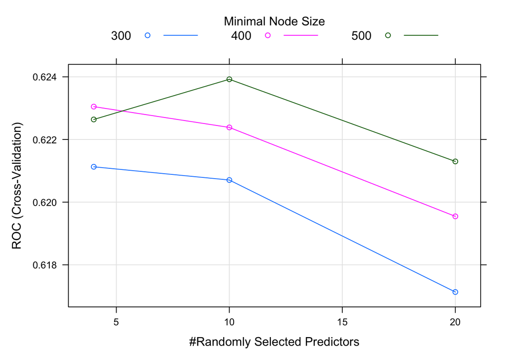

```r
plot(rforest)
```

```r
r.rforest.auc.t
```

```
## Area under the curve: 0.7899
```

```r
r.rforest.auc
```

```
## Area under the curve: 0.6216
```

#### Boosted Tree

Area under the curve: 0.5509 Area under the curve: 0.6236

We still think that this is a little too wide of a difference for us to consider this the final model used.

```r
gb.tree
```

```
## Stochastic Gradient Boosting
##
## 22368 samples
##    61 predictor
##     2 classes: 'No', 'Yes'
##
## No pre-processing
## Resampling: Cross-Validated (10 fold)
## Summary of sample sizes: 20131, 20132, 20131, 20132, 20130, 20131, ...
## Resampling results across tuning parameters:
##
##   shrinkage  interaction.depth  n.trees  ROC        Sens       Spec
##   0.01       20                 100      0.6224537  1.0000000  0.000000000
##   0.01       20                 200      0.6247837  1.0000000  0.000000000
##   0.01       20                 300      0.6250680  1.0000000  0.000000000
##   0.01       40                 100      0.6233758  1.0000000  0.000000000
##   0.01       40                 200      0.6238459  1.0000000  0.000000000
##   0.01       40                 300      0.6228780  1.0000000  0.000000000
##   0.10       20                 100      0.6036940  0.9993058  0.002717213
##   0.10       20                 200      0.5875117  0.9974700  0.004947323
##   0.10       20                 300      0.5779027  0.9947910  0.010824258
##   0.10       40                 100      0.5950945  0.9983131  0.004540200
##   0.10       40                 200      0.5784047  0.9942945  0.011357790
##   0.10       40                 300      0.5703322  0.9922102  0.014945876
##
## Tuning parameter 'n.minobsinnode' was held constant at a value of 50
## ROC was used to select the optimal model using the largest value.
## The final values used for the model were n.trees = 300, interaction.depth =
##  20, shrinkage = 0.01 and n.minobsinnode = 50.
```

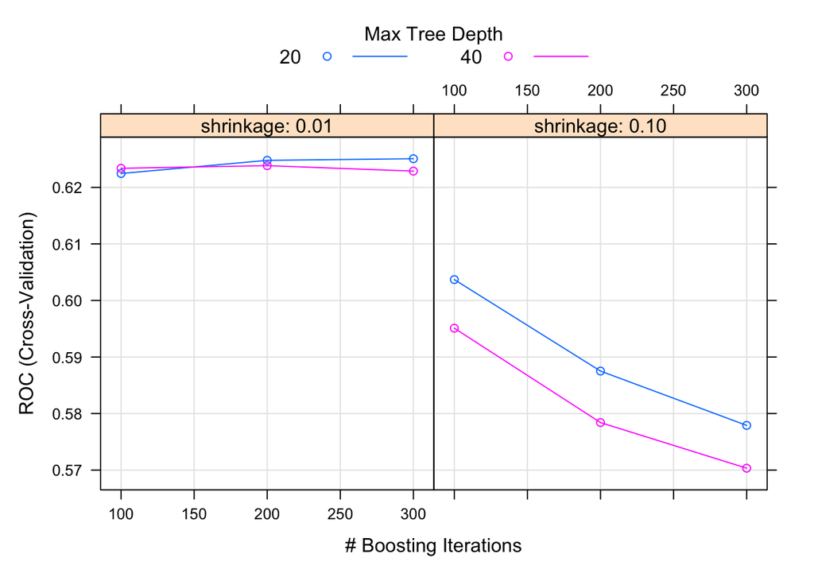

```r
plot(gb.tree)
```

```r
r.gbtree.auc.t
```

```
## Area under the curve: 0.5509
```

```r
r.gbtree.auc
```

```
## Area under the curve: 0.6236
```

#### XGBBoost

Area under the curve: 0.5509 Area under the curve: 0.6138

AUC Difference: 0.0629

```r
xgboost
```

```
## eXtreme Gradient Boosting
##
## 22368 samples
##    61 predictor
##     2 classes: 'No', 'Yes'
##
## No pre-processing
## Resampling: Cross-Validated (10 fold)
## Summary of sample sizes: 20131, 20132, 20131, 20132, 20130, 20131, ...
## Resampling results across tuning parameters:
##
##   eta    max_depth  gamma  colsample_bytree  min_child_weight  subsample
##   0.001   6         0.50   0.3                0                0.3
##   0.001   6         0.50   0.3                0                1.0
##   0.001   6         0.50   0.3               30                0.3
##   0.001   6         0.50   0.3               30                1.0
##   0.001   6         0.50   1.0                0                0.3
##   0.001   6         0.50   1.0                0                1.0
##   0.001   6         0.50   1.0               30                0.3
##   0.001   6         0.50   1.0               30                1.0
##   0.001   6         0.75   0.3                0                0.3
##   0.001   6         0.75   0.3                0                1.0
##   0.001   6         0.75   0.3               30                0.3
##   0.001   6         0.75   0.3               30                1.0
##   0.001   6         0.75   1.0                0                0.3
##   0.001   6         0.75   1.0                0                1.0
##   0.001   6         0.75   1.0               30                0.3
##   0.001   6         0.75   1.0               30                1.0
##   0.001  12         0.50   0.3                0                0.3
##   0.001  12         0.50   0.3                0                1.0
##   0.001  12         0.50   0.3               30                0.3
##   0.001  12         0.50   0.3               30                1.0
##   0.001  12         0.50   1.0                0                0.3
##   0.001  12         0.50   1.0                0                1.0
##   0.001  12         0.50   1.0               30                0.3
##   0.001  12         0.50   1.0               30                1.0
##   0.001  12         0.75   0.3                0                0.3
##   0.001  12         0.75   0.3                0                1.0
##   0.001  12         0.75   0.3               30                0.3
##   0.001  12         0.75   0.3               30                1.0
```

[output cut: 92 more lines]

```
##   0.5978776  0.9996518  0.0014090236
##   0.5763179  0.9960815  0.0058496630
##   0.5872425  0.9992555  0.0022946608
##   0.6166484  1.0000000  0.0000000000
##   0.6065924  0.9998010  0.0000000000
##   0.5752560  0.9939964  0.0125183270
##   0.5890335  0.9977693  0.0072252815
##   0.6076427  0.9999498  0.0004444444
##   0.6008331  0.9995530  0.0013968470
##
## Tuning parameter 'nrounds' was held constant at a value of 200
## ROC was used to select the optimal model using the largest value.
## The final values used for the model were nrounds = 200, max_depth = 6, eta
##  = 0.001, gamma = 0.5, colsample_bytree = 1, min_child_weight = 30
##  and subsample = 0.3.
```

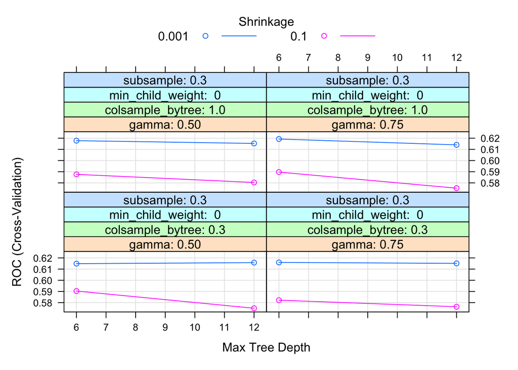

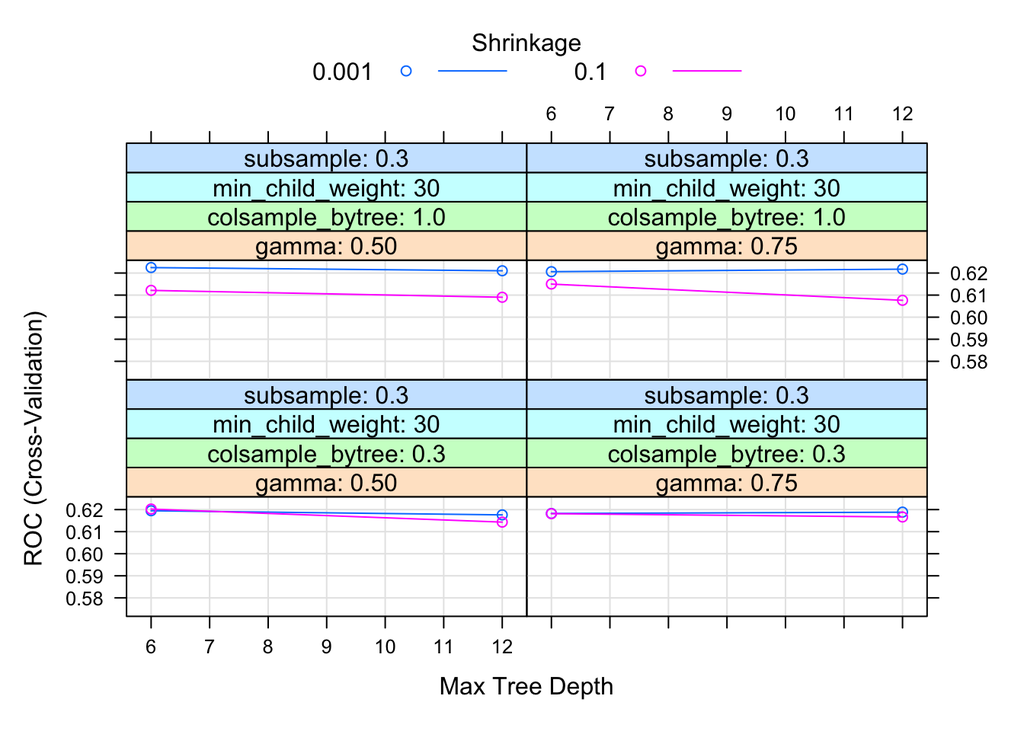

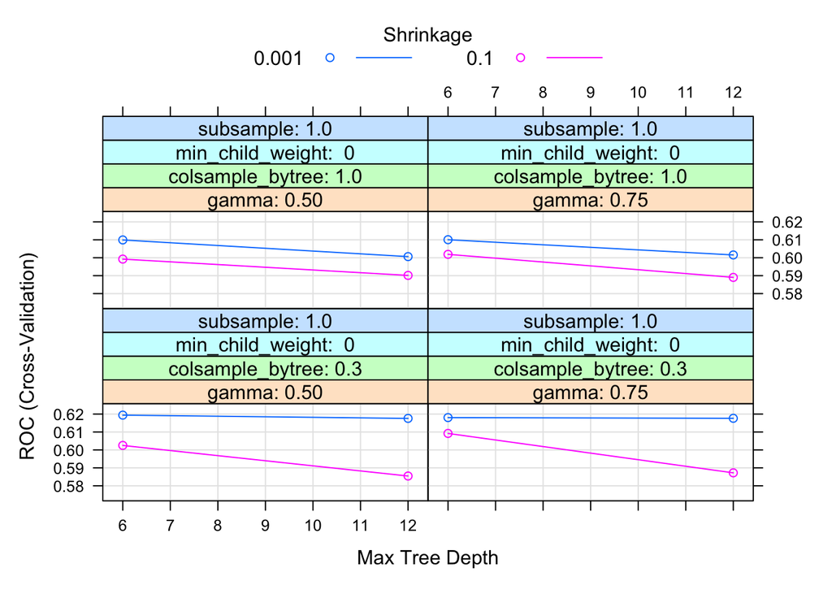

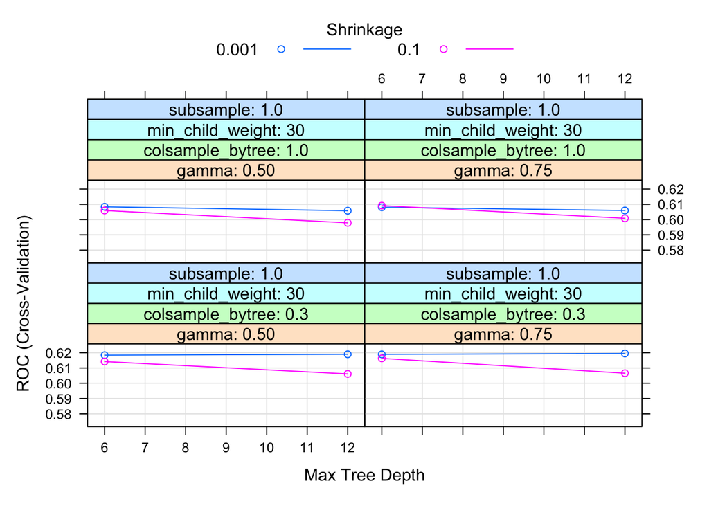

```r
plot(xgboost)
```

```r
r.xgboost.auc.t
```

```
## Area under the curve: 0.5509
```

```r
r.xgboost.auc
```

```
## Area under the curve: 0.6138
```

#### Linear Stepwise

```r
lrstep
```

```
## Generalized Linear Model with Stepwise Feature Selection
##
## 22368 samples
##    61 predictor
##     2 classes: 'No', 'Yes'
##
## No pre-processing
## Resampling: None
```

#### Second Order Stepwise

```r
step2
```

```
## retained ~ (ConfirmCodeY + ClassSize + GPA + ACTComposite + ACTEng +
##     ACTMath + ACTWRSC + AcadRS + `AlmostFullRaceNon-White` +
##     AlmostFullRaceWhite + AlumniConnection_O + `\`AlumniConnection_O - Other\`` +
##     AlumniConnection_S + AlumniConnection_NA + Division_AP +
##     Division_BU + Division_EA + Division_FSB + ApplicationType_OF +
##     ApplicationType_OM + DecisionType_H + DecisionType_K + DecisionType_NA +
##     HsType_2 + HsType_3 + HsType_Public + HsType_NA + ON_3 +
##     ON_4 + MiamiRanks_noFAFSA + WhichTestBest_ACT + WhichTestBest_SAT +
##     SuppMajor3_APEE)^2
```

#### Neural Network with Logistic Terms

```r
nnetFit
```

```
## Neural Network
##
## 22368 samples
##     0 predictor
##     2 classes: 'No', 'Yes'
##
## Pre-processing:  (None)
## Resampling: Cross-Validated (10 fold)
## Summary of sample sizes: 20131, 20132, 20131, 20132, 20130, 20131, ...
## Resampling results across tuning parameters:
##
##   size  decay  ROC        Sens  Spec
##    1    0.0    0.4998429  1     0
##    1    0.1    0.4987136  1     0
##    1    0.5    0.4990350  1     0
```

[output cut: 30 more lines]

### Comparison

#### ROC Objects

```r
results<-data.frame(valid$retained, p.gbtree[,2], p.xgboost[,2])
```

#### Lift

```r
pred6<-prediction(results$p.xgboost, results$valid.retained)
lift6<-performance(pred6, "lift", "rpp")
plot(lift6,main="Lift chart", col="brown1", ylim=c(0,2))

varImp(xgboost)

confusionMatrix(data=results$Cut, reference=results$valid.retained, positive="No")
```

[output not shown]

```r
pred<-prediction(results$ps, results$valid.retained)
pred2<-prediction(results$psit, results$valid.retained)
pred3<-prediction(results$p.rforest, results$valid.retained)
pred4<-prediction(results$p.gbtree, results$valid.retained)
pred5<-prediction(results$p.nnet, results$valid.retained)
pred6<-prediction(results$p.xgboost, results$valid.retained)
lift<-performance(pred, "lift", "rpp")
lift2<-performance(pred2, "lift", "rpp")
lift3<-performance(pred3, "lift", "rpp")
lift4<-performance(pred4, "lift", "rpp")
lift5<-performance(pred5, "lift", "rpp")
lift6<-performance(pred6, "lift", "rpp")
plot(lift,main="Lift chart", col="brown1", ylim=c(0,2))
plot(lift2, col="blue", add=T)
plot(lift3, col="chocolate2", add=T)
plot(lift4, col="chartreuse", add=T)
plot(lift5, col="darkmagenta", add=T)
plot(lift6, col="black", add=T)
legend(0.6, 1, legend=c("First Order Log", "Second Order Log", "Random Forest", "Boosted Tree", "NN1", "xgboost"),
       col=c("brown1", "blue", "chocolate2", "chartreuse", "darkmagenta", "black"), lty=1, cex=0.8)
```

[output not shown]

```r
plot(lift,main="Lift chart-zoom", col="brown1", ylim=c(0,2), xlim=c(0,0.3))
plot(lift2, col="blue", add=T)
plot(lift3, col="chocolate2", add=T)
plot(lift4, col="chartreuse", add=T)
plot(lift5, col="darkmagenta", add=T)
plot(lift6, col="black", add=T)
legend(0.05, 1, legend=c("First Order Log", "Second Order Log", "Random Forest", "Boosted Tree", "NN1", "xgboost"),
       col=c("brown1", "blue", "chocolate2", "chartreuse", "darkmagenta", "black"), lty=1, cex=0.8)
```

[output not shown]

#### ROC

```r
p<-ggroc(roc)
p+scale_color_discrete(name="Model")+theme_bw()+xlab("True Negative Rate")+ylab("True Positive Rate")
```

[output not shown]

```r
roc<-list( "Step"=ps, "Sec.Order"=psit, "Random Forest"=r.rforest, "Small Tree"=r.small.valid, "GB Tree"=r.gbtree, "XGBoost"=r.xgbtree)

p<-ggroc(roc)
p+scale_color_discrete(name="Model")+theme_bw()
```

[output not shown]

#### Cutoff Analysis

```r
df<-data.frame(lift6@y.values,  lift6@alpha.values)
colnames(df)<-c("lift", "cutoff")
head(df)

coords(rt,"best", ret="threshold")
```

[output not shown]